# Marketing Mix Modeling

*Marketing Mix Modeling* (MMM) is a classical problem in Marketing analysis, and argubly the most important one. Marketing mix refers to all the marketing efforts a company puts in, and it often refers to the 4P’s, i.e. Price, Promotion, Product and Place (channel). Marketing mix modeling analyzes the effects of those efforts. However, in most cases, Marketing Mix Modeling refers to the model analysis on only promptional dollars (such as advertising) spend across multiple marketing media channels.

## Different Types of Marketing Mix Modeling

There are different ways of classifying Marketing Mix Modeling. One way is to group it based on the type of data used: **aggregate** level analysis vs. **individual** level analysis.

*Before the digital age* offers big data to the marketing field, marketing promotion data are primarily at aggregate level. Aggregate level data means no recards of individual customers. Instead, they record the marketing expenditures over *traditional media channels*, for different products, at different geographic locations, over time. In addition to these aggregate level promotional data, companies also record the sales data for each product, at different geographic locations, over time. In such situation, a most common approach to analyze the effect of these different promotions through different media channal is a multiple regression model.

*In the digital age*, as customers spend more time online, many promotional activities happend online as well. Those activities may include, but not limited to, email communications with the customers, keywords ads on Google, ads on facebook, etc. Two major reasons that online marketing is so attractive to marketers are:

- First, it is *much cheaper* than traditional marketing media, such as TV ads. For example, showing a 30 seconds vedio ads on Superbowl in 2015 costs about $4M. The same vedio ads may cost a few dollars on youtube.
- Second, online ads can be *tracked*. Although $4.5M are spent on superbowl, it is impossible for the advertiser to gauge who are those consumers that actually saw the ads. This issue has created the classical frustration to marketers, as demonstrated in the famous quote by [John Wanamaker](https://en.wikipedia.org/wiki/John_Wanamaker) “I know half of my advertising dollars are wasted … I just don’t know which half.” Online ads can be tracked for at individual level. For example, if Santa Clara University marketing team bid the keywords “MBA”. Google knows who saw the SCU MBA ads on google’s page, who clicked on the ads, and when this happend.

## Marketing Mix Modeling using Traditional Media Channels

When Online Marketing first gained popularity at the beginning of this century, it is widely believed that online marketing will take the place of traditional mass media marketing. Almost 20 years later, we still see large expenditures in traditional media channels, such as TV, newspaper, radio, etc. This is especially true for traditional consumer products. Although over time, the total expenditures on traditional media has been decreasing, while the online marketing expenditures has been rising.

In this section, we discuss the MMM for the traditional media channels using *Linear Regression* models.

The data is from an auto company, containing its monthly sales of cars during about 4-year period spanning January 2012 to December 2015, together with the ads expenses on different media channesl during the same period. For privacy reason, the name of the company cannot be disclosed, and the data are also rescaled.

```r
cardf = read.csv("sales_ads_use.csv", header=TRUE, sep=",")
```

As discussed before, in order to setup a linear regression model, we need to find the Y variable and the X variables. The Y variable is usually an outcome varaible that we care about. In this case, it is the number of cars sold in each month. The question is what should be the X variables? A convenient practice is to include all the other variables in the data as X variables.

**Remember: Before any modeling, do plot the data, and understand the data generating process really thoroughly.**

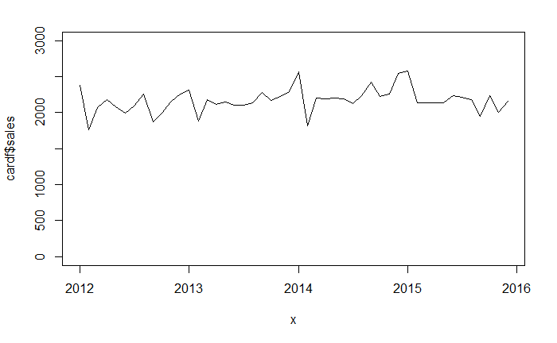

```r
yr = cardf$year
mn = cardf$month
yrmn = yr*100+mn
yrmndt =paste(as.character(yrmn),"01",sep="")
x = as.Date(yrmndt,"%Y%m%d")
plot(x,cardf$sales,type="l",ylim=c(0,3000))
```

> Q: Before setting up the model, what data do you think you would need that would influence automobile sales?

We will never get all the data we need, but it is important to know what we don’t have and think about the consequences of missing those information in the modeling exercise.

**Remember: When setting up the model, imagine you are the person making the purchase decision, and think about what factors might influence your purchase decisions. List those factors and variables, before checking on what are the variables included in the data.**

Let’s start our model with
$$sales_t=\beta_0+\beta_1\times Newspaper_t +\beta_2\times Magazine_t +\beta_3\times Radio_t+\beta_4\times TV_t+\epsilon_t$$

```r
Xvars = as.matrix(cardf[,4:7])
Yval = cardf[,3]
lm_basic = lm(Yval~Xvars)
summary(lm_basic)
```

```
Call:
lm(formula = Yval ~ Xvars)

Residuals:
    Min      1Q  Median      3Q     Max
-288.77  -65.83  -16.84   52.10  425.56

Coefficients:
                 Estimate Std. Error t value Pr(>|t|)
(Intercept)    2027.03084   46.20294  43.872  < 2e-16 ***
Xvarsnewspaper    0.12553    0.18851   0.666    0.509
Xvarsmagazine    -0.01457    0.10507  -0.139    0.890
Xvarsradio        0.29668    0.06665   4.451 5.96e-05 ***
Xvarstv           0.10484    0.08189   1.280    0.207
---
Signif. codes:  0 *** 0.001 ** 0.01 * 0.05 . 0.1   1

Residual standard error: 142.6 on 43 degrees of freedom
Multiple R-squared:  0.3255,    Adjusted R-squared:  0.2627
F-statistic: 5.187 on 4 and 43 DF,  p-value: 0.001685
```

One issue is that the current setup assumes that the marketing expenses only influences the sales in the current month, not those in the later months. Is this the case for automobile purchases?

As people tend to spend more than a month when deciding to purchase a big ticket item, such as a car, the instantaneous impact assumption in this model may not hold. There are multiple ways to deal with this problem.

#### Lagged X variables

First, if you believe the advertising effects last one month, we can allow the last month’s expenses to influence this month’s sales. To do that, we estimate a slightly different model, that is

$$sales_t=\beta_0+\beta_1\times Newspaper_{t-1} +\beta_2\times Magazine_{t-1} +\beta_3\times Radio_{t-1}+\beta_4\times TV_{t-1}+\epsilon_t$$
In order to do this analysis, you need to process the data to get it ready. The X variables would be from time=1 to time=N-1. The Y variable will take the alues from time=2 to time=N.

> Q: How many data points do we have now?

We lost one row of data when we need a lag 1 variable. We would lose two rows of data when we need lag2 variable. We would lose N rows of data when we need lagN variable.

```r
N=length(Yval)
Xvarlag = Xvars[1:(N-1),]
Yvalnew=Yval[2:N]
lm_lagX=lm(Yvalnew~Xvarlag)
summary(lm_lagX)
```

```
Call:
lm(formula = Yvalnew ~ Xvarlag)

Residuals:
    Min      1Q  Median      3Q     Max
-380.72  -65.83   -2.88   69.95  386.01

Coefficients:
                   Estimate Std. Error t value Pr(>|t|)
(Intercept)      2159.19780   51.71971  41.748   <2e-16 ***
Xvarlagnewspaper    0.03697    0.21055   0.176    0.861
Xvarlagmagazine    -0.19732    0.11744  -1.680    0.100
Xvarlagradio        0.10930    0.07438   1.469    0.149
Xvarlagtv          -0.09345    0.09137  -1.023    0.312
---
Signif. codes:  0 *** 0.001 ** 0.01 * 0.05 . 0.1   1

Residual standard error: 159.2 on 42 degrees of freedom
Multiple R-squared:  0.1494,    Adjusted R-squared:  0.06842
F-statistic: 1.845 on 4 and 42 DF,  p-value: 0.1383
```

In this estimation, we lagged all the X variables in the model.

> Q: can we lag some of the X variables, not all of them?

#### Lagged Y variables

If you believe some consistency of car sales exists, we should add a lagged Y variable. Similarly, we create the data needed first.

```r
lagY=Yval[1:(N-1)]
Xvarsnew= Xvars[2:N,]
lm_lagY = lm(Yvalnew~Xvarsnew+lagY)
summary(lm_lagY)
```

```
Call:
lm(formula = Yvalnew ~ Xvarsnew + lagY)

Residuals:
    Min      1Q  Median      3Q     Max
-277.05  -57.39  -10.03   34.85  432.83

Coefficients:
                    Estimate Std. Error t value Pr(>|t|)
(Intercept)       1806.14844  293.56256   6.153 2.63e-07 ***
Xvarsnewnewspaper    0.23274    0.17920   1.299   0.2013
Xvarsnewmagazine    -0.08016    0.10375  -0.773   0.4442
Xvarsnewradio        0.33573    0.06341   5.295 4.32e-06 ***
Xvarsnewtv           0.15539    0.08367   1.857   0.0705 .
lagY                 0.08680    0.12846   0.676   0.5030
---
Signif. codes:  0 *** 0.001 ** 0.01 * 0.05 . 0.1   1

Residual standard error: 132.6 on 41 degrees of freedom
Multiple R-squared:  0.4234,    Adjusted R-squared:  0.3531
F-statistic: 6.022 on 5 and 41 DF,  p-value: 0.0002888
```

> Q: How do you compare this model with lagged Y with the basic model?

The new variable lagY is not statistically significant, however, it does improve the adjusted R-square (0.3531202) comparing to that in the basic model (0.2627192).

#### Dummy variables

Let’s revisit the sales plot, using a different scale in plotting it.

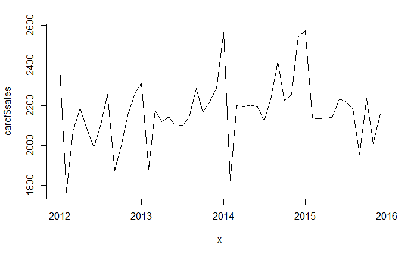

```r
plot(x,cardf$sales,type="l")
```

It makes clear that there are significant drops in February, for the Chinese new year period. So, we can consider adding dummy variables, to represent the seasonality.

A dummy variable only takes two possible values, 0 and 1. In this data, we want to set it so that only in February it takes the value 1, and 0 otherwise, which will capture the possible Chinese new year effect.

```r
Feb = c(rep(0,N))
Feb[cardf$month==2] =1
Feb = Feb[-1]
lm_feb = lm(Yvalnew~Xvarsnew+lagY+Feb)
summary(lm_feb)
```

```
Call:
lm(formula = Yvalnew ~ Xvarsnew + lagY + Feb)

Residuals:
    Min      1Q  Median      3Q     Max
-242.40  -72.67   -5.20   51.84  361.63

Coefficients:
                    Estimate Std. Error t value Pr(>|t|)
(Intercept)       1377.87809  284.40410   4.845 1.94e-05 ***
Xvarsnewnewspaper    0.11673    0.16094   0.725 0.472491
Xvarsnewmagazine    -0.08658    0.09131  -0.948 0.348711
Xvarsnewradio        0.23712    0.06216   3.815 0.000462 ***
Xvarsnewtv           0.10033    0.07520   1.334 0.189693
lagY                 0.32207    0.13057   2.467 0.018023 *
Feb               -289.79016   80.51860  -3.599 0.000870 ***
---
Signif. codes:  0 *** 0.001 ** 0.01 * 0.05 . 0.1   1

Residual standard error: 116.7 on 40 degrees of freedom
Multiple R-squared:  0.5645,    Adjusted R-squared:  0.4991
F-statistic:  8.64 on 6 and 40 DF,  p-value: 4.776e-06
```

To compare the predicted values and the actual data visually, we can plot them using the “rbokeh” package and the functions it provided. You could also use the “ggplot2” package.

```r
library(rbokeh)
p = figure()
p %>% ly_points(x[-1],y=Yvalnew,legend="Sales data",xlab="Time",ylab="Sales", hover=Yvalnew) %>%
      ly_lines(x[-1],y=fitted(lm_feb),legend="Predicted Sales", col="red")
```

[interactive chart not shown]

> Q: why the predicted values do not form a straight line?

#### Interaction Variables

There have been beliefs that doing marketing needs to use multiple channels. We can test using our data to see whether having more than one channel together could provide additional lift. To test that, we add an interaction term in the regression model.

```r
radioTV = Xvarsnew[,3]*Xvarsnew[,4]
lm_intact_rdtv = lm(Yvalnew~Xvarsnew+radioTV + lagY+Feb)
summary(lm_intact_rdtv)
```

```
Call:
lm(formula = Yvalnew ~ Xvarsnew + radioTV + lagY + Feb)

Residuals:
    Min      1Q  Median      3Q     Max
-240.03  -67.58  -10.14   57.48  381.72

Coefficients:
                    Estimate Std. Error t value Pr(>|t|)
(Intercept)        1.363e+03  2.776e+02   4.909 1.67e-05 ***
Xvarsnewnewspaper  1.969e-01  1.636e-01   1.203 0.236074
Xvarsnewmagazine  -4.163e-02  9.274e-02  -0.449 0.656012
Xvarsnewradio      3.254e-01  7.905e-02   4.117 0.000193 ***
Xvarsnewtv         2.300e-01  1.045e-01   2.200 0.033774 *
radioTV           -3.757e-04  2.158e-04  -1.741 0.089509 .
lagY               3.050e-01  1.278e-01   2.387 0.021928 *
Feb               -2.453e+02  8.260e+01  -2.970 0.005077 **
---
Signif. codes:  0 *** 0.001 ** 0.01 * 0.05 . 0.1   1

Residual standard error: 113.8 on 39 degrees of freedom
Multiple R-squared:  0.5959,    Adjusted R-squared:  0.5234
F-statistic: 8.215 on 7 and 39 DF,  p-value: 3.954e-06
```

```r
newsmag = Xvarsnew[,1]*Xvarsnew[,2]
lm_intact_nwmg = lm(Yvalnew~Xvarsnew+newsmag + lagY+Feb)
summary(lm_intact_nwmg)
```

```
Call:
lm(formula = Yvalnew ~ Xvarsnew + newsmag + lagY + Feb)

Residuals:
    Min      1Q  Median      3Q     Max
-240.76  -72.14   -6.82   52.70  361.66

Coefficients:
                    Estimate Std. Error t value Pr(>|t|)
(Intercept)        1.368e+03  2.985e+02   4.584 4.61e-05 ***
Xvarsnewnewspaper  1.347e-01  2.197e-01   0.613 0.543407
Xvarsnewmagazine  -6.672e-02  1.874e-01  -0.356 0.723698
Xvarsnewradio      2.356e-01  6.422e-02   3.668 0.000728 ***
Xvarsnewtv         1.008e-01  7.624e-02   1.322 0.193860
newsmag           -1.819e-04  1.493e-03  -0.122 0.903652
lagY               3.265e-01  1.371e-01   2.381 0.022252 *
Feb               -2.917e+02  8.299e+01  -3.515 0.001132 **
---
Signif. codes:  0 *** 0.001 ** 0.01 * 0.05 . 0.1   1

Residual standard error: 118.2 on 39 degrees of freedom
Multiple R-squared:  0.5646,    Adjusted R-squared:  0.4865
F-statistic: 7.226 on 7 and 39 DF,  p-value: 1.494e-05
```

```r
newsmagrad = Xvarsnew[,1]*Xvarsnew[,2]*Xvarsnew[,3]
lm_intact_nwmgrd = lm(Yvalnew~Xvarsnew+newsmagrad + lagY+Feb)
summary(lm_intact_nwmgrd)
```

```
Call:
lm(formula = Yvalnew ~ Xvarsnew + newsmagrad + lagY + Feb)

Residuals:
    Min      1Q  Median      3Q     Max
-267.30  -75.26   -3.76   60.43  376.69

Coefficients:
                    Estimate Std. Error t value Pr(>|t|)
(Intercept)        1.314e+03  2.873e+02   4.572 4.78e-05 ***
Xvarsnewnewspaper  2.133e-01  1.779e-01   1.199 0.237816
Xvarsnewmagazine   5.246e-02  1.444e-01   0.363 0.718430
Xvarsnewradio      2.891e-01  7.470e-02   3.870 0.000403 ***
Xvarsnewtv         1.504e-01  8.496e-02   1.770 0.084544 .
newsmagrad        -5.059e-06  4.090e-06  -1.237 0.223487
lagY               3.348e-01  1.301e-01   2.573 0.014007 *
Feb               -2.703e+02  8.153e+01  -3.315 0.001985 **
---
Signif. codes:  0 *** 0.001 ** 0.01 * 0.05 . 0.1   1

Residual standard error: 115.9 on 39 degrees of freedom
Multiple R-squared:  0.5809,    Adjusted R-squared:  0.5057
F-statistic: 7.723 on 7 and 39 DF,  p-value: 7.584e-06
```

> Q: Given the interaction variable between radio and TV expenditure. What’s the marginal impact of 1 unit increase in radio expense on sales?

It is important to understand the interpretations of the parameter estimates for interaction variables. Interaction variables could be critical in the context of fraud detection, for example. It is not a parcicular store the person is shopping at increases the possibility of being a fraud. It is the fact that a particular person shops at a particular store at a particular time, or the interactions of these three variables, that make it very likely to be a fraud.

Then the question is how do you interpret the parameter estimates of the interaction variable. When two X variables are interacted, such as radio and TV, the marginal impact of TV on sales is a function of how much spent on radio. The model we estimated with the radio and TV interaction variable is
$$sales_t=\beta_0+\beta_1\times Newspaper_t +\beta_2\times Magazine_t +\beta_3\times Radio_t+\beta_4\times TV_t+\beta_5\times Radio_t\times TV_t+\beta_6\times sales_{t-1}+\beta_7\times Feb_t +\epsilon_t$$
Holding everything else constant, increasing radio expenses by 1 unit, the marginal impact on sales is $\hat{\beta_3}+\hat{\beta_5}\times TV_t$, which is a function of how much they spend on TV in the same time period.

> Q: How do you interpret the sign of the parameter estimate for $\hat{\beta_5}$?

#### Nonlinear Transformation of X variables

In the above regression model, all the X variables are included in a linear form. This indicates that regardless of the current X value, a unit increase in an X value would lead to the same increase in Y. This is the same when X is very small, and when X value is really big.

If you believe that putting to much money into marketing may have diminishing returns, you can consider nonlinear transofrmation of the X variables.

Nonline trasnformation means that you take a nonline function of the X variable first, before including the transformed X values into the regression models. In our context, for diminishing returns, the two most popular ways to get that is using

- adding a squared term of the X variable
- using a ln-transformation $ln()$ of the X variable.

When we do add a square term, we also keep the linear term in the model as well. To do that

```r
Xvarsnew2 = Xvarsnew^2/1000
lm_sqr= lm(Yvalnew~Xvarsnew+Xvarsnew2+lagY+Feb)
summary(lm_sqr)
```

```
Call:
lm(formula = Yvalnew ~ Xvarsnew + Xvarsnew2 + lagY + Feb)

Residuals:
    Min      1Q  Median      3Q     Max
-158.20  -51.45  -23.14   33.09  349.73

Coefficients:
                     Estimate Std. Error t value Pr(>|t|)
(Intercept)        1291.07074  296.60990   4.353 0.000106 ***
Xvarsnewnewspaper    -0.43542    0.62544  -0.696 0.490786
Xvarsnewmagazine     -0.19457    0.25849  -0.753 0.456519
Xvarsnewradio         0.51091    0.22272   2.294 0.027734 *
Xvarsnewtv            0.10600    0.16352   0.648 0.520930
Xvarsnew2newspaper    1.59238    1.29344   1.231 0.226260
Xvarsnew2magazine     0.25192    0.27975   0.901 0.373828
Xvarsnew2radio       -0.20708    0.17398  -1.190 0.241734
Xvarsnew2tv           0.05462    0.14925   0.366 0.716544
lagY                  0.33237    0.13561   2.451 0.019238 *
Feb                -232.95942   92.26359  -2.525 0.016119 *
---
Signif. codes:  0 *** 0.001 ** 0.01 * 0.05 . 0.1   1

Residual standard error: 115 on 36 degrees of freedom
Multiple R-squared:  0.6193,    Adjusted R-squared:  0.5136
F-statistic: 5.856 on 10 and 36 DF,  p-value: 3.466e-05
```

Ok, this is obvious, squared term does not make sense in this context. Squared term also has another problem, that is, after certain value, the X variable increase will lead to Y value decrease. You may find a hard time to convince your Marketing people with such a result. An alternative way to capture diminishing returns is to use the ln-tranformation. However, the ln-transformation requares all values to be positive. ln(0) will give you -inf. To avoid that, instead of using $ln(x)$, we use $ln(x+1)$, as long as all $x$ take non-negative values.

```r
lnX = log(Xvarsnew+1)
lm_lnx = lm(Yvalnew~lnX+lagY+Feb)
summary(lm_lnx)
```

```
Call:
lm(formula = Yvalnew ~ lnX + lagY + Feb)

Residuals:
    Min      1Q  Median      3Q     Max
-245.91  -73.00  -15.59   84.00  293.03

Coefficients:
              Estimate Std. Error t value Pr(>|t|)
(Intercept)  1377.9760   305.6010   4.509 5.57e-05 ***
lnXnewspaper    3.4024    17.1230   0.199  0.84350
lnXmagazine    -9.7530    14.7589  -0.661  0.51251
lnXradio       43.7531    17.3168   2.527  0.01558 *
lnXtv          -7.1099     7.1766  -0.991  0.32779
lagY            0.2809     0.1409   1.993  0.05315 .
Feb          -307.5498    91.4917  -3.362  0.00172 **
---
Signif. codes:  0 *** 0.001 ** 0.01 * 0.05 . 0.1   1

Residual standard error: 124.2 on 40 degrees of freedom
Multiple R-squared:  0.5064,    Adjusted R-squared:  0.4323
F-statistic: 6.839 on 6 and 40 DF,  p-value: 4.792e-05
```

To check the model fit comparison, we put all the adjusted R-square values together.

```r
adj.rsq.all=c(basic=summary(lm_basic)$adj.r.squared,lagY=summary(lm_lagY)$adj.r.squared,radtv=summary(lm_intact_rdtv)$adj.r.squared, nwmg=summary(lm_intact_nwmg)$adj.r.squared, nwmgrd=summary(lm_intact_nwmgrd)$adj.r.squared, xsqr=summary(lm_sqr)$adj.r.squared,lnx=summary(lm_lnx)$adj.r.squared )
adj.rsq.all
```

```
    basic      lagY     radtv      nwmg    nwmgrd      xsqr       lnx
0.2627192 0.3531202 0.5233572 0.4864936 0.5056921 0.5135597 0.4323452
```

> Q: which model do you think is the best.

Bottom line is do NOT rely only on the statistical results, also need to think about the application contexts.

#### Using a Different Y?

As Marketing may work on improving what happend before, it is common for analyst to use the change in sales value as the Y variable, instead of the actual sales Value. To do that, we just need to create the new Y value

```r
dY = Yvalnew-lagY
lm_dY = lm(dY~Xvarsnew+Feb)
summary(lm_dY)
```

```
Call:
lm(formula = dY ~ Xvarsnew + Feb)

Residuals:
    Min      1Q  Median      3Q     Max
-350.98  -74.32  -14.77   87.72  332.76

Coefficients:
                    Estimate Std. Error t value Pr(>|t|)
(Intercept)        -79.38945   58.62669  -1.354   0.1831
Xvarsnewnewspaper    0.09837    0.20562   0.478   0.6349
Xvarsnewmagazine    -0.00762    0.11505  -0.066   0.9475
Xvarsnewradio        0.18625    0.07844   2.374   0.0223 *
Xvarsnewtv           0.19225    0.09340   2.058   0.0459 *
Feb               -499.08218   89.07251  -5.603 1.59e-06 ***
---
Signif. codes:  0 *** 0.001 ** 0.01 * 0.05 . 0.1   1

Residual standard error: 149.1 on 41 degrees of freedom
Multiple R-squared:  0.6244,    Adjusted R-squared:  0.5785
F-statistic: 13.63 on 5 and 41 DF,  p-value: 7.527e-08
```

The adjusted R square value seems to have improved a lot comparing to all the other models we got so far.

```r
p = figure()
p %>% ly_points(x[-1],y=dY,legend="Sales Change",xlab="Time",ylab="Sales change", hover=dY) %>%
      ly_lines(x[-1],y=fitted(lm_dY),legend="Predicted Sales Change", col="red")
```

[interactive chart not shown]